# Avaliação do Projeto Primeiro Emprego sob a Ótica dos Pontos Focais: Análise Comparativa Longitudinal (2025–2026)

Supervisão cotidiana, acolhimento institucional, comunicação intersetorial e conformidade operacional no serviço público baiano

Autor

Afiliação

Fernando Antonio de Melo Pereira Lhamas

Universidade Federal do Rio Grande do Norte (UFRN) | Núcleo de Pós-Graduação em Administração (NPGA/UFBA)

Data de Publicação

setembro de 2026

# 1 Sumário Executivo

A presente pesquisa avaliativa examina a implementação, a operação prática e a governança do **Projeto Primeiro Emprego (PPE)** a partir da perspectiva dos **Pontos Focais** — servidores, coordenadores e gestores públicos que supervisionam diretamente o cotidiano laboral dos jovens beneficiários nas secretarias, autarquias, hospitais gerais e policlínicas estaduais da Bahia.

Com base em um delineamento empírico longitudinal comparando os ciclos de **2025 ($N = 67$)** e **2026 ($N = 77$)**, totalizando **144 gestores públicos**, o estudo oferece um panorama robusto sobre os sucessos formativos e os gargalos de gestão da política pública.

| Dimensão Avaliada | ✅ Principais Fortalezas Observadas | ⚠️ Pontos Críticos e Riscos Operacionais |
| --- | --- | --- |
| **Relevância Social** | Validação quase unânime da política pública como indutora indispensável de empregabilidade para a juventude egressa da EPT. | Elevada expectativa de suporte técnico e pedagógico nem sempre suprida na ponta do serviço. |
| **Acolhimento Inicial** | Recepção humanizada e bem estruturada, com adesão crescente a protocolos e diretrizes formais de integração. | Disparidades entre unidades hospitalares complexas e pequenos órgãos administrativos quanto aos recursos de recepção. |
| **Comunicação Interinstitucional** | Uso ágil de canais digitais (WhatsApp e E-mail) para resolução pontual de dúvidas e demandas cotidianas. | Percepção de ruídos de comunicação com a entidade parceira gestora (FESF-SUS/FLEM), gerando assimetria informacional sobre prorrogações contratuais. |
| **Desempenho e Adaptação** | Alta proatividade, excelente relacionamento interpessoal com as equipes permanentes e rápida adaptação à cultura pública. | O manejo da imaturidade juvenil como desafio prático e a carência de instrumentos sistemáticos e objetivos de avaliação contínua. |
| **Conformidade Operacional** | Reconhecimento generalizado do PPE como ambiente virtuoso de aprendizado prático em serviço. | Casos isolados com risco de desvio de finalidade (cobertura indevida de postos permanentes em unidades desfalcadas). |

# 2 Introdução e Contexto Institucional

O sucesso de programas de inserção laboral para jovens egressos da Educação Profissional e Tecnológica (EPT) não decorre exclusivamente da concessão de bolsas de estágio ou contrato especial de trabalho, mas da **qualidade da experiência formativa no posto de atuação**. Nesse desenho institucional, a figura do **Ponto Focal** assume centralidade estratégica: atua como mentor pedagógico, supervisor operacional e mediador de conflitos no ambiente do serviço público.

Na Bahia, o PPE mobiliza centenas de órgãos da administração direta e indireta. A eficácia da política depende criticamente da disposição e das condições objetivas de trabalho dos pontos focais para acolher os jovens, transmitir competências profissionais e assegurar uma transição protegida para o mundo do trabalho formal.

```
graph TD
    A["Governo do Estado da Bahia<br>(SETRE / SEC / SESAB)"] --> B["Entidade Gestora Parceira<br>(FESF-SUS / FLEM)"]
    B --> C["Pontos Focais<br>(Gestores e Supervisores Locais)"]
    C --> D["Jovens Beneficiários do PPE<br>(Trabalhadores Educandos)"]

    C -.->|"Acolhimento & Orientação"| D
    C -.->|"Supervisão de Frequência & Metas"| D
    B -.->|"Suporte Técnico & Contratual"| C
```

# 3 Nota Técnica e Metodologia

## 3.1 Coleta de Dados e Perfil Amostral

A pesquisa com gestores foi realizada mediante aplicação de questionário estruturado online, desenvolvido e administrado pela equipe de monitoramento do PPE/FESF-SUS em dois períodos correspondentes:

1. **Ciclo Avaliativo de 2025:** 67 respondentes (coletas efetuadas entre 03 de setembro e 23 de outubro de 2025);
2. **Ciclo Avaliativo de 2026:** 77 respondentes (coletas efetuadas entre 07 de maio e 18 de junho de 2026);
3. **Amostra Consolidada:** 144 questionários integralmente respondidos, sem perdas amostrais ou registros incompletos em nenhuma das 20 questões normativas.

## 3.2 Tratamento, Harmonização e Reprodutibilidade Científica

Os dados foram auditados e processados em conformidade com o script `gest_02_tratamento_dados_2026.R`, estruturados em um pipeline reprodutível de ciência de dados: * **Linguagem R (R Core Team, 2024):** Utilizada como ambiente computacional estatístico unificado; * **Ecossistema Tidyverse (Wickham et al., 2019, 2023):** Empregado para higienização, tipagem estrita de fatores ordenados Likert e transformações tabulares auditáveis; * **Visualização de Dados e Storytelling with Data (Wickham, 2016; Wickham; Pedersen; Seidel, 2023):** Padronização gráfica minimalista com foco pré-atentivo deliberado, paleta institucional coerente e eliminação de sobrecargas visuais; * **Tipificação Estrita e Harmonização:** Conversão das escalas Likert de 1 a 5 em fatores ordenados e categorização semântica padronizada para as questões abertas (`q2`, `q4`, `q5`, `q7`, `q11`, `q12`, `q19` e `q20`), garantindo cálculo confiável das variações em pontos percentuais (`p.p.`).

# 4 Percepção Geral do Projeto e o Papel do Ponto Focal

A compreensão da eficácia do Projeto Primeiro Emprego exige a análise da perspectiva dos gestores públicos locais que exercem a função de **Ponto Focal**. São esses profissionais que convertem as diretrizes estratégicas da política pública em práticas cotidianas de acolhimento, distribuição de tarefas, mediação formativa e fiscalização de frequência.

## 4.1 Relevância Global do PPE para a Juventude Baiana

A avaliação inicia-se com a mensuração da relevância atribuída ao PPE pelos gestores em uma escala de 1 (“nada relevante”) a 5 (“extremamente relevante”). A Tabela 1 apresenta as frequências e as variações longitudinais entre 2025 e 2026.

Tabela 1: Distribuição dos Pontos Focais quanto à relevância do PPE na inserção de jovens no trabalho (2025 vs. 2026).

| Nível de Relevância Declarada | 2025 (N) | 2025 (%) | 2026 (N) | 2026 (%) | Variação (p.p.) |
| --- | --- | --- | --- | --- | --- |
| 1 - Nada relevante | 0 | 0,0% | 0 | 0,0% | 0,0 |
| 2 - Pouco relevante | 1 | 1,5% | 0 | 0,0% | -1,5 |
| 3 - Moderadamente | 4 | 6,0% | 1 | 1,3% | -4,7 |
| 4 - Muito relevante | 10 | 14,9% | 9 | 11,7% | -3,2 |
| 5 - Extremamente relevante | 52 | 77,6% | 67 | 87,0% | +9,4 |
| Total | 67 | 100,0% | 77 | 100,0% | — |

A evolução das proporções relativas na escala de relevância é ilustrada na Figura 1.

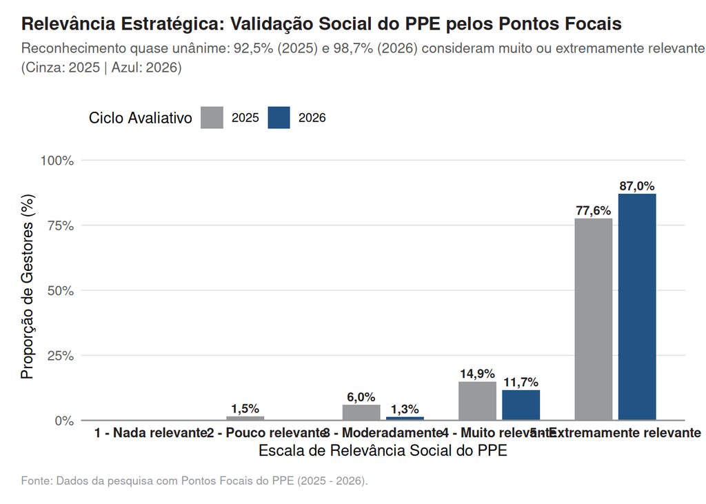

Figura 1: Comparativo longitudinal da percepção de relevância do PPE entre gestores em 2025 e 2026.

Os resultados empíricos atestam uma consagração institucional inequívoca da política pública: * **Hegemonia da Validação Positiva (92,5% para 98,7%):** Somando-se as notas 4 e 5, a relevância do programa foi chancelada por **92,5%** dos gestores em 2025 e atingiu extraordinários **98,7%** em 2026 (**+6,2 pontos percentuais**); * **Salto na Pontuação Máxima (+9,4 p.p.):** A categoria máxima “Extremamente relevante” saltou de **77,6%** (52 gestores) para **87,0%** (67 gestores), comprovando que o amadurecimento operacional do programa reforçou a convicção gerencial de que o PPE é essencial para a transição dos egressos da EPT; * **Inexistência de Rejeição:** Em 2026, nenhum respondente assinalou notas 1 ou 2, restando apenas um único respondente na faixa neutra (nota 3, 1,3%).

## 4.2 Atribuições Práticas e Perfil de Atuação do Ponto Focal

Para compreender como a tutoria é exercida na prática, os gestores indicaram sua atribuição prioritária na unidade de trabalho. A Tabela 2 e a Figura 2 discriminam os perfis funcionais declarados.

Tabela 2: Distribuição da principal atribuição prática desempenhada como Ponto Focal do PPE (2025 vs. 2026).

| Principal Atribuição como Ponto Focal | 2025 (N) | 2025 (%) | 2026 (N) | 2026 (%) | Variação (p.p.) |
| --- | --- | --- | --- | --- | --- |
| Orientação e supervisão direta | 24 | 35,8% | 30 | 39,0% | +3,2 |
| Acompanhamento de desempenho e frequência | 20 | 29,9% | 24 | 31,2% | +1,3 |
| Outras atribuições (Mediação e rotinas) | 23 | 34,3% | 23 | 29,9% | -4,4 |
| Total | 67 | 100,0% | 77 | 100,0% | — |

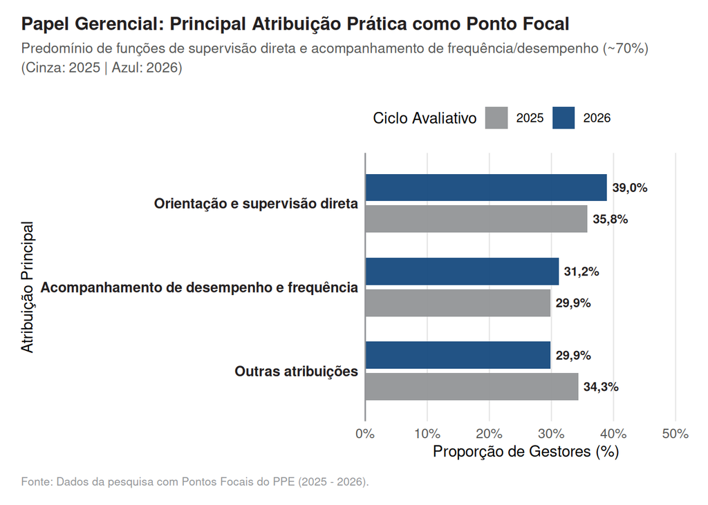

Figura 2: Perfil funcional prioritário desempenhado pelos gestores e pontos focais do PPE.

A configuração das atribuições evidencia: * **Foco Pedagógico e Supervisão Direta:** A função de “Orientação e supervisão direta das atividades dos jovens” é preponderante, concentrando **35,8%** das menções em 2025 e avançando para **39,0%** em 2026 (**+3,2 p.p.**). Esse dado é auspicioso, pois demonstra que os gestores compreendem seu papel prioritariamente como mentores de aprendizagem profissional em serviço; * **Fiscalização de Desempenho e Frequência:** O acompanhamento formal de assiduidade e entrega laboral representa o segundo maior bloco, congregando **29,9%** em 2025 e **31,2%** em 2026; * **Coprovedoria e Mediação (30% a 34%):** As demais atribuições envolvem tarefas mistas de resolução de conflitos, contato com chefias intermediárias e articulação institucional com a entidade parceira.

## 4.3 Nível Geral de Desafio da Função de Ponto Focal

Exercer a função de Ponto Focal impõe conciliar as rotinas habituais do serviço público com a mentoria de jovens em início de carreira. A escala de complexidade de 1 (“nada desafiador”) a 5 (“extremamente desafiador”) é reportada na Tabela 3 e na Figura 3.

Tabela 3: Distribuição do grau de desafio geral associado à função de Ponto Focal (2025 vs. 2026).

| Nível Geral de Desafio da Função | 2025 (N) | 2025 (%) | 2026 (N) | 2026 (%) | Variação (p.p.) |
| --- | --- | --- | --- | --- | --- |
| 1 - Nada desafiador | 3 | 4,5% | 1 | 1,3% | -3,2 |
| 2 - Pouco desafiador | 5 | 7,5% | 5 | 6,5% | -1,0 |
| 3 - Moderadamente | 12 | 17,9% | 18 | 23,4% | +5,5 |
| 4 - Muito desafiador | 27 | 40,3% | 32 | 41,6% | +1,3 |
| 5 - Extremamente desafiador | 20 | 29,9% | 21 | 27,3% | -2,6 |
| Total | 67 | 100,0% | 77 | 100,0% | — |

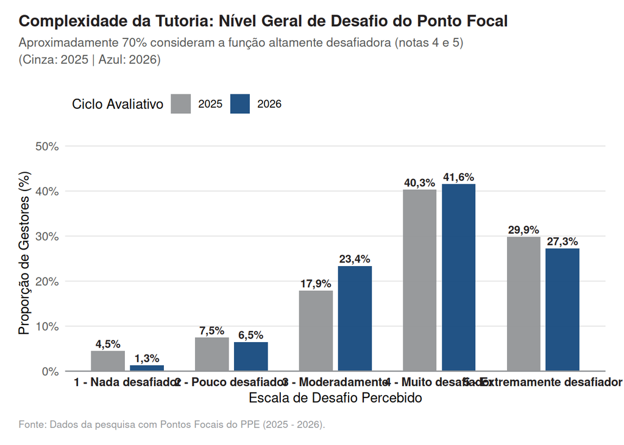

Figura 3: Nível de complexidade e desafio percebido pelos gestores no acompanhamento do PPE.

## 4.4 Principais Desafios Enfrentados na Supervisão Cotidiana

A análise textual e a categorização semântica das 144 respostas discursivas da questão `q4` permitiram identificar quatro grandes eixos de constrangimento operacional, consolidados na Tabela 4 e na Figura 4.

Tabela 4: Eixos temáticos dos principais desafios enfrentados pelos Pontos Focais na tutoria cotidiana (2025 vs. 2026).

| Eixo Temático dos Desafios Relatados | 2025 (N) | 2025 (%) | 2026 (N) | 2026 (%) | Variação (p.p.) |
| --- | --- | --- | --- | --- | --- |
| Falta de tempo e sobrecarga das rotinas habituais | 15 | 22,4% | 15 | 19,5% | -2,9 |
| Imaturidade, disciplina e postura profissional juvenil | 11 | 16,4% | 17 | 22,1% | +5,7 |
| Falhas de comunicação e suporte lento da entidade parceira | 11 | 16,4% | 14 | 18,2% | +1,8 |
| Infraestrutura deficitária e desvio/ausência de pessoal permanente | 5 | 7,5% | 2 | 2,6% | -4,9 |
| Total de Respondentes com Menções Qualitativas | 67 | 100,0% | 77 | 100,0% | — |

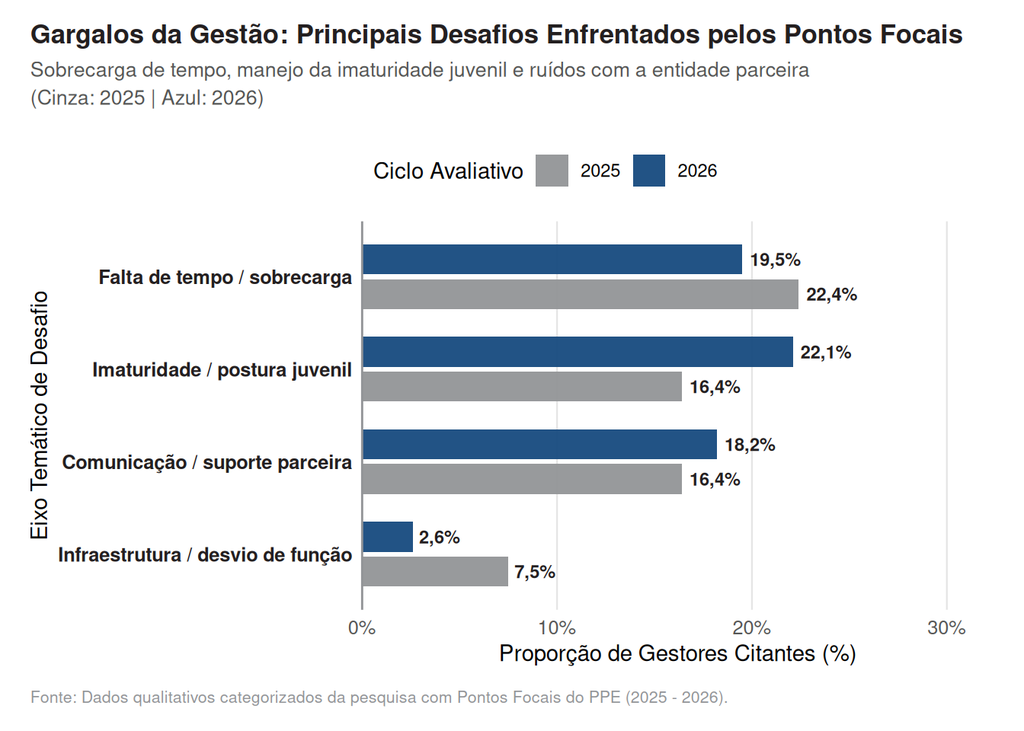

Figura 4: Frequência relativa dos eixos de desafios relatados pelos gestores do PPE.

## 4.5 Principais Facilidades e Aspectos Positivos Vivenciados

Em contrapartida às dificuldades, os gestores apontaram as potencialidades e satisfações geradas pela atuação no PPE. A categorização das respostas de `q5` consta na Tabela 5 e na Figura 5.

Tabela 5: Eixos temáticos das principais facilidades e aspectos positivos destacados pelos Pontos Focais (2025 vs. 2026).

| Eixo Temático das Facilidades e Aspectos Positivos | 2025 (N) | 2025 (%) | 2026 (N) | 2026 (%) | Variação (p.p.) |
| --- | --- | --- | --- | --- | --- |
| Apoio, acolhimento e engajamento da equipe de trabalho | 16 | 23,9% | 28 | 36,4% | +12,5 |
| Diálogo aberto, escuta ativa e empatia na relação | 19 | 28,4% | 23 | 29,9% | +1,5 |
| Orientação formativa, mentoria e transmissão de conhecimentos | 17 | 25,4% | 21 | 27,3% | +1,9 |
| Satisfação em acompanhar o crescimento e evolução do jovem | 8 | 11,9% | 17 | 22,1% | +10,2 |
| Total de Respondentes com Menções Qualitativas | 67 | 100,0% | 77 | 100,0% | — |

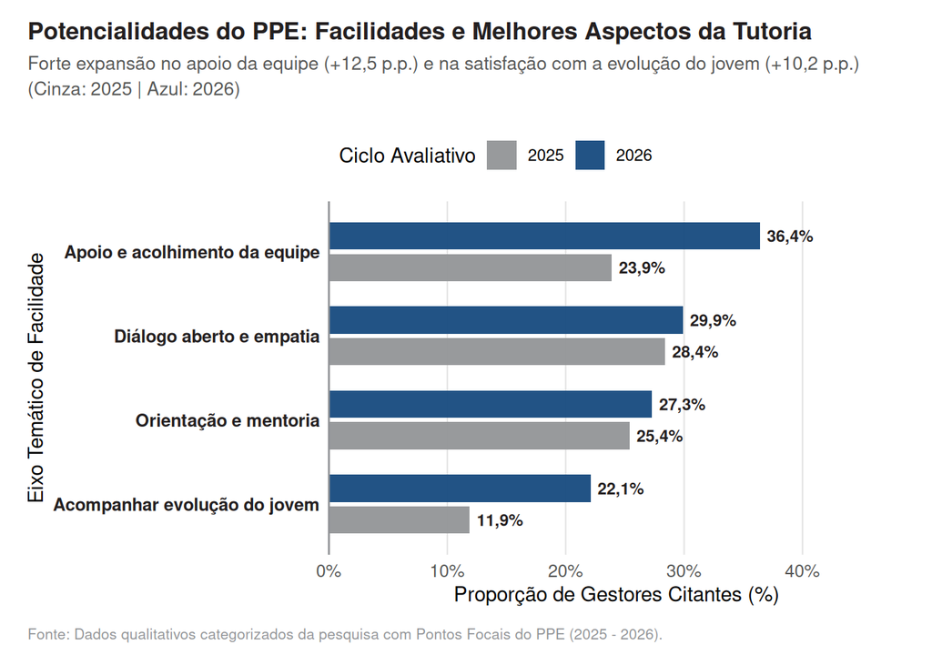

Figura 5: Dimensões positivas e fatores de sucesso destacados pelos gestores na tutoria do PPE.

As forças motrizes do PPE evidenciam: * **Acolhimento Coletivo e Engajamento da Equipe (+12,5 p.p.):** O apoio dos demais servidores e a receptividade do coletivo de trabalho registraram o maior salto proporcional, avançando de **23,9%** em 2025 para **36,4%** em 2026. A equipe institucional assume a co-responsabilidade no acolhimento dos jovens; * **Diálogo Aberto, Empatia e Escuta Ativa (~29-30%):** A construção de vínculos horizontais e canais francos de comunicação com os jovens viabiliza a superação de atritos e favorece a confiança mútua; * **Prazer da Mentoria e Evolução Profissional (+10,2 p.p.):** O reconhecimento de que a formação técnica dos jovens é potencializada no posto gerou um salto expressivo na categoria “Acompanhar a evolução e crescimento do jovem”, que praticamente dobrou de frequência, indo de **11,9%** para **22,1%** em 2026. Esse dado atesta a alta gratificação psicológica e ética dos servidores públicos ao atuarem como mestres profissionais de uma nova geração.*

# 5 Acolhimento, Protocolos e Inserção Organizacional

O acolhimento inicial consubstancia o momento fundador da experiência do jovem no Projeto Primeiro Emprego. É na chegada ao posto de trabalho que se estabelece o contrato psicológico, alinham-se as expectativas operacionais e mitiga-se a ansiedade inerente à estreia no mundo laboral formal.

## 5.1 Avaliação Global do Processo de Recepção dos Jovens

Os gestores avaliaram a qualidade do acolhimento oferecido em suas repartições em uma escala de 1 (“Muito insatisfatório”) a 5 (“Muito satisfatório”). Os dados consolidados constam na Tabela 6 e na Figura 6.

Tabela 6: Distribuição dos Pontos Focais quanto à avaliação do processo de acolhimento dos jovens no órgão (2025 vs. 2026).

| Avaliação do Processo de Acolhimento | 2025 (N) | 2025 (%) | 2026 (N) | 2026 (%) | Variação (p.p.) |
| --- | --- | --- | --- | --- | --- |
| 1 - Muito insatisfatório | 0 | 0,0% | 1 | 1,3% | +1,3 |
| 2 - Insatisfatório | 1 | 1,5% | 1 | 1,3% | -0,2 |
| 3 - Regular / Neutro | 4 | 6,0% | 12 | 15,6% | +9,6 |
| 4 - Satisfatório | 25 | 37,3% | 26 | 33,8% | -3,5 |
| 5 - Muito satisfatório | 37 | 55,2% | 37 | 48,1% | -7,1 |
| Total | 67 | 100,0% | 77 | 100,0% | — |

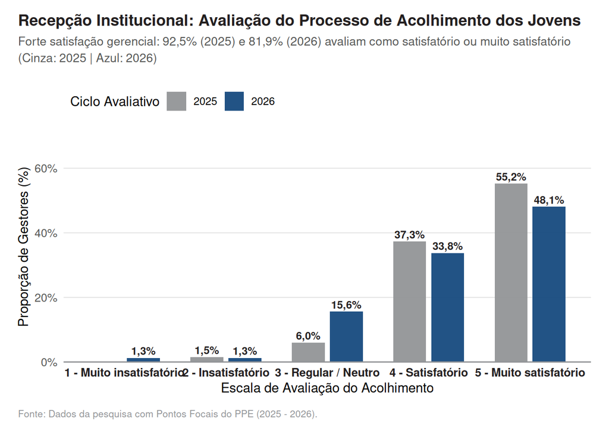

Figura 6: Avaliação do acolhimento inicial dos beneficiários na percepção dos gestores públicos.

Os resultados empíricos atestam: * **Forte Satisfação Agregada (81,9% a 92,5%):** A recepção inicial dos educandos nas unidades públicas mantém índices expressivos de aprovação gerencial, reunindo **92,5%** de notas 4 e 5 em 2025 e **81,9%** em 2026; * **Crescimento da Zona de Neutralidade (+9,6 p.p.):** Observa-se uma ampliação na avaliação neutra/regular (nota 3), que passou de **6,0%** (4 gestores) para **15,6%** (12 gestores) em 2026. Esse movimento decorre da interiorização acelerada do programa e do ingresso de novos órgãos parceiros, cuja infraestrutura física e de recepção ainda carece de consolidação; * **Insatisfação Residual Inexpressiva (~2%):** Apenas 2 gestores em 2026 assinalaram notas 1 e 2 (2,6%), demonstrando que o acolhimento é um dos pilares de maior êxito e menor atrito no PPE.

## 5.2 Institucionalização Normativa: Existência de Protocolos Padronizados

A maturidade de uma política pública reflete-se na transição de práticas informais e discricionárias para procedimentos operacionais padronizados. A Tabela 7 e a Figura 7 reportam a proporção de unidades que dispõem de diretrizes formais de acolhimento.

Tabela 7: Proporção de órgãos que possuem protocolos ou diretrizes formais para acolhimento do PPE (2025 vs. 2026).

| Órgão Possui Protocolos de Acolhimento? | 2025 (N) | 2025 (%) | 2026 (N) | 2026 (%) | Variação (p.p.) |
| --- | --- | --- | --- | --- | --- |
| Sim (Possui protocolos padronizados) | 43 | 64,2% | 54 | 70,1% | +5,9 |
| Não (Não possui diretrizes formais) | 12 | 17,9% | 6 | 7,8% | -10,1 |
| Não tenho certeza / Talvez | 12 | 17,9% | 17 | 22,1% | +4,2 |
| Total | 67 | 100,0% | 77 | 100,0% | — |

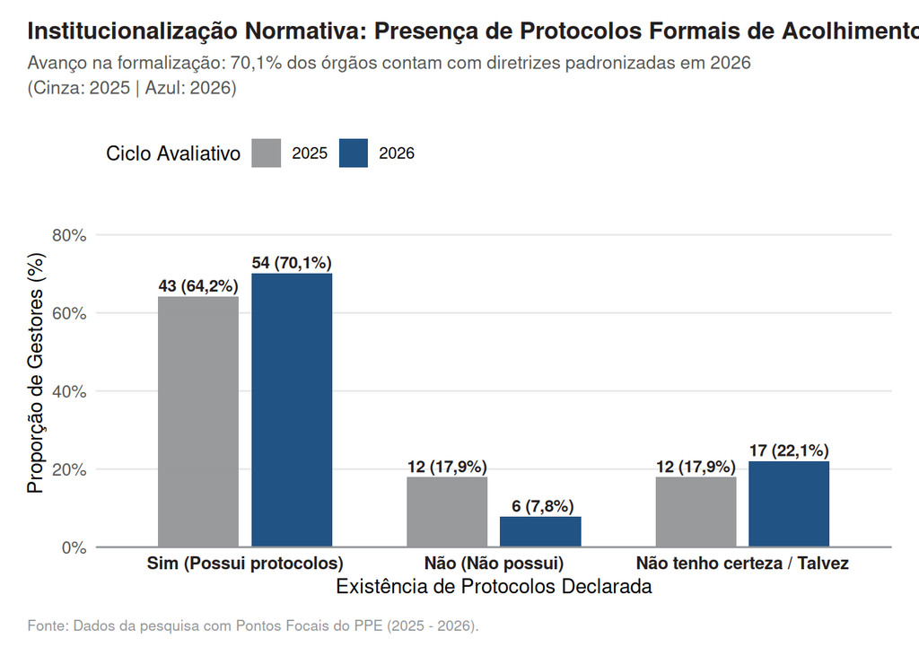

Figura 7: Evolução da formalização de diretrizes e manuais de acolhimento nos órgãos estaduais.

A análise da governança normativa destaca: * **Avanço na Padronização Institucional (+5,9 p.p.):** A parcela de órgãos com protocolos escritos saltou de **64,2%** em 2025 (43 unidades) para **70,1%** em 2026 (54 unidades), demonstrando um ciclo virtuoso de aprendizagem organizacional no serviço público baiano; * **Queda Expressiva da Ausência de Diretrizes (-10,1 p.p.):** As unidades que declararam não possuir nenhuma diretriz recuaram fortemente de **17,9%** para apenas **7,8%** (6 órgãos); * **O Desafio da Disseminação Informativa (22,1%):** Cerca de um quinto dos gestores em 2026 declarou não ter certeza sobre a existência de manuais ou protocolos em sua instituição, apontando a necessidade de maior divulgação interna dos materiais orientativos da FESF-SUS.

## 5.3 Contribuição do Acolhimento para a Integração na Equipe

A importância estratégica da recepção inicial é mensurada pelo grau em que os gestores consideram o acolhimento determinante para a socialização do jovem, conforme sintetizado na Tabela 8 e na Figura 8.

Tabela 8: Percepção da contribuição do acolhimento para a integração dos beneficiários na equipe (2025 vs. 2026).

| Contribuição do Acolhimento para a Integração | 2025 (N) | 2025 (%) | 2026 (N) | 2026 (%) | Variação (p.p.) |
| --- | --- | --- | --- | --- | --- |
| É fundamental | 41 | 61,2% | 51 | 66,2% | +5,0 |
| Contribui significativamente | 20 | 29,9% | 26 | 33,8% | +3,9 |
| Contribui em alguma medida | 6 | 9,0% | 0 | 0,0% | -9,0 |
| Total | 67 | 100,0% | 77 | 100,0% | — |

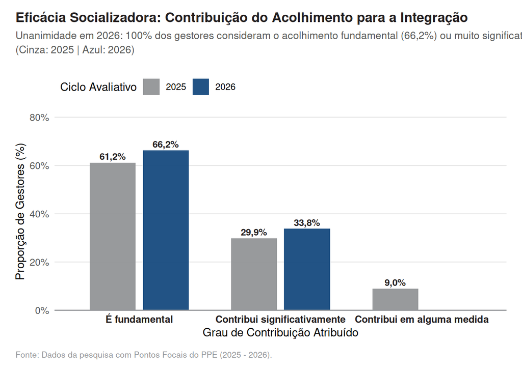

Figura 8: Grau de relevância atribuído ao acolhimento como indutor da integração funcional.

Os dados revelam um consenso absoluto: * **Unanimidade em 2026 (100,0%):** A totalidade dos 77 gestores pesquisados em 2026 categorizou o acolhimento como “É fundamental” (**66,2%**, +5,0 p.p.) ou “Contribui significativamente” (**33,8%**, +3,9 p.p.); * **Erradicação da Visão Marginal:** Nenhuma menção a “Contribui apenas em alguma medida” foi registrada em 2026, confirmando que os pontos focais reconhecem o acolhimento não como mera formalidade burocrática, mas como condição *sine qua non* para a eficiência e o bem-estar no trabalho.

## 5.4 Modos de Socialização e Inserção na Cultura Organizacional

A incorporação dos jovens nos valores e práticas do serviço público ocorre por meio de diferentes estratégias pedagógicas e de convivência. A Tabela 9 e a Figura 9 mapeiam os modelos predominantes.

Tabela 9: Formas de inserção do jovem beneficiário na cultura organizacional do órgão (2025 vs. 2026).

| Forma de Inserção na Cultura do Órgão | 2025 (N) | 2025 (%) | 2026 (N) | 2026 (%) | Variação (p.p.) |
| --- | --- | --- | --- | --- | --- |
| Acompanhamento por servidor mais experiente (mentoria) | 38 | 56,7% | 40 | 51,9% | -4,8 |
| Múltiplas práticas integradas (reuniões, eventos, manuais) | 19 | 28,4% | 25 | 32,5% | +4,1 |
| Apresentação formal inicial à equipe | 10 | 14,9% | 12 | 15,6% | +0,7 |
| Total | 67 | 100,0% | 77 | 100,0% | — |

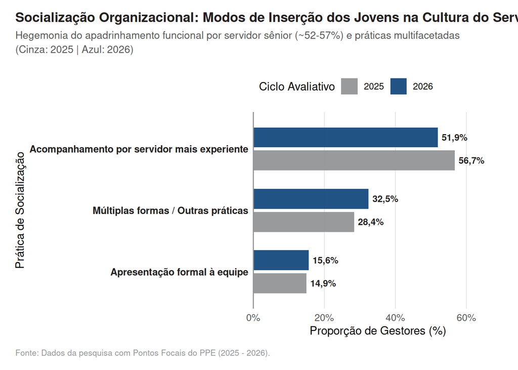

Figura 9: Estratégias de socialização dos beneficiários do PPE na cultura do serviço público.

A morfologia da socialização funcional indica: * **Predomínio do Apadrinhamento por Servidor Sênior (~52-57%):** A designação de um servidor ou colega experiente para tutelar o jovem no posto de trabalho é a prática hegemônica em ambos os ciclos (**56,7%** em 2025 e **51,9%** em 2026). Esse arranjo favorece a transmissão tácita de normas éticas, procedimentos técnicos e rotinas burocráticas; * **Avanço de Práticas Integradas e Multifacetadas (28,4% para 32,5%):** Uma proporção crescente de órgãos conjuga reuniões de equipe, manuais de boas-vindas e participação em eventos de alinhamento; * **Apresentação Formal Inicial (15% a 16%):** Prática complementar adotada para legitimar a presença do beneficiário perante a comunidade de trabalho.*

# 6 Comunicação Interinstitucional, Canais e Supervisão do Desempenho

A eficácia da supervisão do Projeto Primeiro Emprego reside na articulação harmônica entre a gestão central do programa, as entidades parceiras operacionais executoras (FESF-SUS / FLEM) e os órgãos estaduais demandantes. Esta seção analisa a avaliação dos fluxos comunicacionais com a entidade parceira, os canais de contato preferenciais, a frequência de supervisão e os gargalos enfrentados pelos gestores para a obtenção de dados e suporte institucional.

## 6.1 Avaliação da Qualidade e Agilidade da Comunicação com a Entidade Parceira

A questão `q10` mensurou a avaliação dos pontos focais acerca da agilidade, clareza e presteza da comunicação mantida com a entidade parceira responsável pelo suporte ao projeto em uma escala Likert de 1 (“Muito insatisfatória”) a 5 (“Muito satisfatória”). A distribuição longitudinal é reportada na Tabela 10 e na Figura 10.

Tabela 10: Avaliação da qualidade e agilidade da comunicação com a entidade parceira do PPE (2025 vs. 2026).

| Qualidade da Comunicação com a Entidade Parceira | 2025 (N) | 2025 (%) | 2026 (N) | 2026 (%) | Variação (p.p.) |
| --- | --- | --- | --- | --- | --- |
| 1 - Muito insatisfatório | 6 | 9,0% | 2 | 2,6% | -6,4 |
| 2 - Insatisfatório | 3 | 4,5% | 3 | 3,9% | -0,6 |
| 3 - Regular / Neutro | 12 | 17,9% | 18 | 23,4% | +5,5 |
| 4 - Satisfatório | 28 | 41,8% | 28 | 36,4% | -5,4 |
| 5 - Muito satisfatório | 18 | 26,9% | 26 | 33,8% | +6,9 |
| Total | 67 | 100,0% | 77 | 100,0% | — |

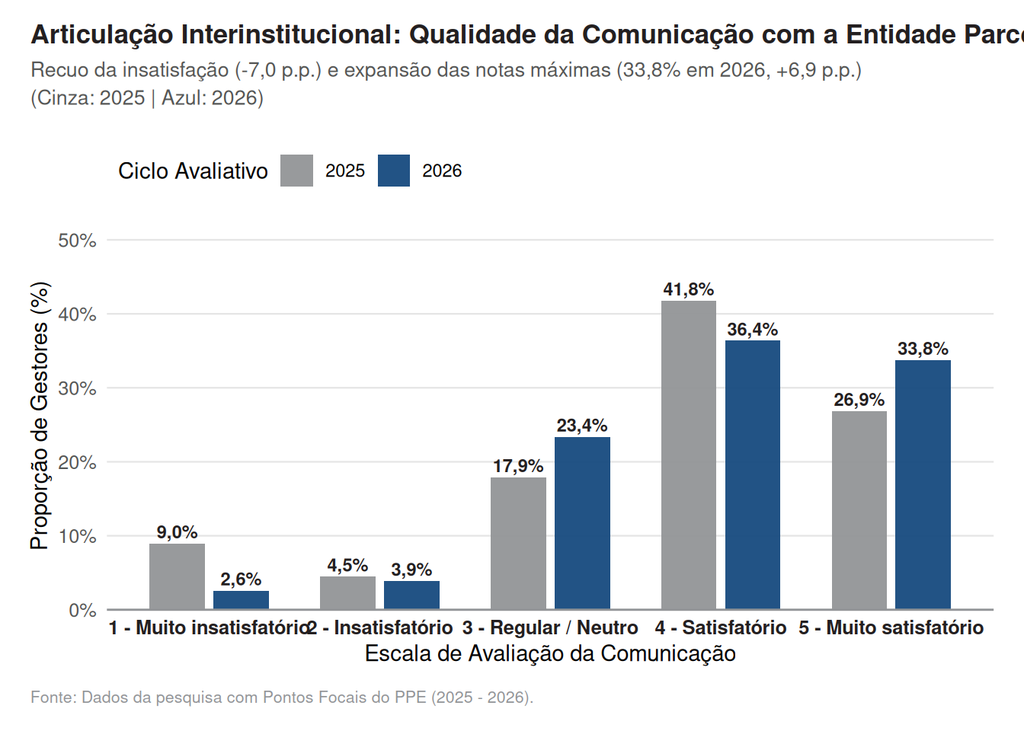

Figura 10: Distribuição da avaliação gerencial sobre a comunicação com a entidade parceira gestora.

## 6.2 Canais Institucionais e Vias de Contato Utilizadas

A identificação das plataformas pelas quais a gestão dos postos dialoga com a coordenação do PPE é fundamental para o desenho de estratégias de atendimento unificado. A Tabela 11 e a Figura 11 consolidam as ferramentas mobilizadas pelos gestores (questão `q11`).

Tabela 11: Principais canais de comunicação utilizados pelos Pontos Focais com a entidade parceira (2025 vs. 2026).

| Canal de Comunicação com a Entidade Parceira | 2025 (N) | 2025 (%) | 2026 (N) | 2026 (%) | Variação (p.p.) |
| --- | --- | --- | --- | --- | --- |
| WhatsApp exclusivo | 37 | 55,2% | 40 | 51,9% | -3,3 |
| E-mail exclusivo | 20 | 29,9% | 25 | 32,5% | +2,6 |
| Outros canais (Plataformas / Presencial) | 8 | 11,9% | 10 | 13,0% | +1,1 |
| Telefone / Contato direto | 1 | 1,5% | 2 | 2,6% | +1,1 |
| WhatsApp e E-mail integrados | 1 | 1,5% | 0 | 0,0% | -1,5 |
| Total | 67 | 100,0% | 77 | 100,0% | — |

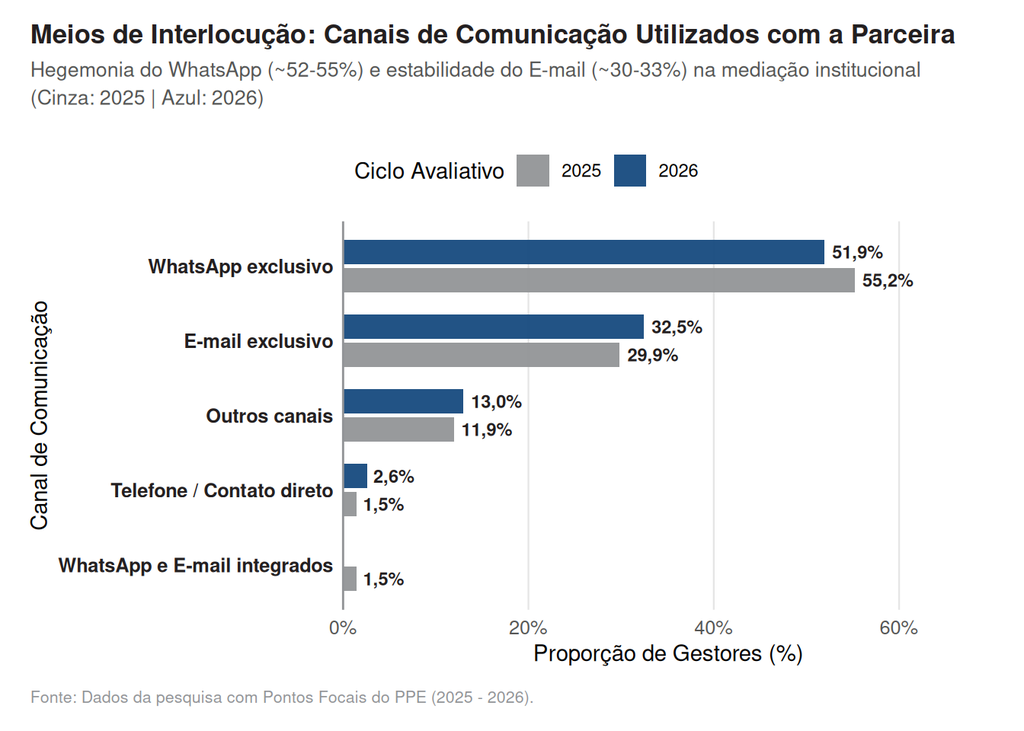

Figura 11: Perfil de utilização de canais e plataformas de comunicação pelos gestores do PPE.

## 6.3 Frequência e Rotina do Acompanhamento Laboral

A supervisão direta e diária confere ao gestor local a capacidade de identificar precocemente deficiências formativas e incentivar o desenvolvimento profissional dos jovens. A Tabela 12 e a Figura 12 detalham a periodicidade desse acompanhamento (questão `q12`).

Tabela 12: Periodicidade de acompanhamento e monitoramento dos beneficiários pelos Pontos Focais (2025 vs. 2026).

| Frequência de Acompanhamento das Atividades | 2025 (N) | 2025 (%) | 2026 (N) | 2026 (%) | Variação (p.p.) |
| --- | --- | --- | --- | --- | --- |
| Diariamente | 34 | 50,7% | 36 | 46,8% | -3,9 |
| Semanalmente | 8 | 11,9% | 10 | 13,0% | +1,1 |
| Quinzenalmente ou Mensalmente | 15 | 22,4% | 23 | 29,9% | +7,5 |
| Raramente / Eventual | 10 | 14,9% | 8 | 10,4% | -4,5 |
| Total | 67 | 100,0% | 77 | 100,0% | — |

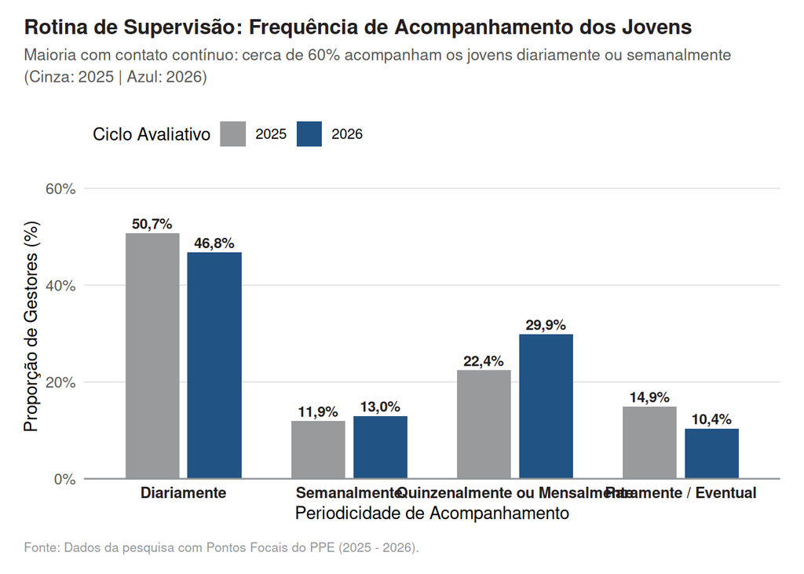

Figura 12: Distribuição da frequência de acompanhamento e tutoria dos jovens no ambiente de trabalho.

## 6.4 Desafios na Obtenção de Informações e Suporte Operacional

Apesar dos avanços de comunicação, o acesso a informações detalhadas de gestão de pessoas e suporte sistêmico aos jovens ainda impõe barreiras. A questão `q13` mensurou o nível de desafio enfrentado pelos pontos focais para obter dados, relatórios e esclarecimentos (escala 1 a 5), conforme exposto na Tabela 13 e na Figura 13.

Tabela 13: Nível de desafio enfrentado para obter informações e suporte da coordenação/parceira (2025 vs. 2026).

| Desafio para Obter Dados de Desempenho e Permanência | 2025 (N) | 2025 (%) | 2026 (N) | 2026 (%) | Variação (p.p.) |
| --- | --- | --- | --- | --- | --- |
| 1 - Nada desafiador | 7 | 10,4% | 10 | 13,0% | +2,6 |
| 2 - Pouco desafiador | 11 | 16,4% | 13 | 16,9% | +0,5 |
| 3 - Moderadamente | 19 | 28,4% | 17 | 22,1% | -6,3 |
| 4 - Muito desafiador | 17 | 25,4% | 26 | 33,8% | +8,4 |
| 5 - Extremamente desafiador | 13 | 19,4% | 11 | 14,3% | -5,1 |
| Total | 67 | 100,0% | 77 | 100,0% | — |

[figure not shown]

Figura 13: Grau de desafio gerencial na obtenção tempestiva de informações e alinhamentos operacionais.

# 7 Perfil Comportamental, Atitudes e Integração dos Beneficiários

A inserção de jovens recém-egressos da educação profissional pública no ambiente estatal requer o desenvolvimento simultâneo de competências técnico-operacionais e de atributos sociocomportamentais (*soft skills*). Sob o olhar dos pontos focais — que atuam como tutores e observadores privilegiados do cotidiano laboral —, esta seção analisa a proatividade dos jovens, o impacto da imaturidade comportamental, a clareza sobre metas de carreira, a adaptação às rotinas públicas e a sociabilidade com os colegas de trabalho.

## 7.1 Proatividade e Iniciativa no Desempenho das Funções

A questão `q14` avaliou o grau de proatividade, autonomia e diligência manifestado pelos educandos na execução de suas tarefas cotidianas (escala de 1 a 5). A Tabela 14 e a Figura 14 evidenciam o comportamento dessa variável entre 2025 e 2026.

Tabela 14: Avaliação da proatividade geral dos beneficiários nas rotinas de trabalho (2025 vs. 2026).

| Proatividade Geral dos Beneficiários | 2025 (N) | 2025 (%) | 2026 (N) | 2026 (%) | Variação (p.p.) |
| --- | --- | --- | --- | --- | --- |
| 1 - Totalmente passivos | 1 | 1,5% | 0 | 0,0% | -1,5 |
| 2 - Pouco proativos | 2 | 3,0% | 2 | 2,6% | -0,4 |
| 3 - Medianamente proativos | 14 | 20,9% | 11 | 14,3% | -6,6 |
| 4 - Muito proativos | 16 | 23,9% | 35 | 45,5% | +21,6 |
| 5 - Altamente proativos | 34 | 50,7% | 29 | 37,7% | -13,0 |
| Total | 67 | 100,0% | 77 | 100,0% | — |

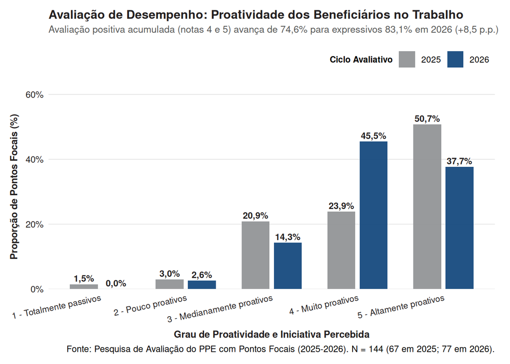

Figura 14: Distribuição percentual da proatividade dos beneficiários segundo os Pontos Focais.

Os resultados apontam uma evolução notável no comprometimento dos educandos: * **Crescimento da Aprovação Agregada (+8,5 p.p.):** A soma dos conceitos positivos (notas 4 e 5) expandiu-se de **74,6%** em 2025 para expressivos **83,1%** em 2026. Os jovens consolidam uma postura dinâmica, prestativa e disposta a solucionar problemas imediatos das unidades; * **Migração para a Nota 4 (+21,6 p.p.):** Observou-se uma forte concentração na nota 4 (“Muito proativos”), que avançou de **23,9%** para **45,5%**, denotando uma avaliação mais equilibrada e criteriosa por parte dos tutores; * **Erradicação da Passividade Crítica (0,0%):** Nenhum gestor assinalou a nota 1 em 2026, e as notas 1 e 2 somadas representaram ínfimos **2,6%**, confirmando o alto valor funcional agregado pelos jovens às repartições estaduais.

## 7.2 Imaturidade Comportamental como Desafio Gerencial

Apesar da postura proativa, a transição entre o ambiente escolar e a disciplina do serviço público expõe lacunas de socialização profissional. A questão `q15` mensurou quão desafiadora é a imaturidade dos beneficiários para o exercício da tutoria gerencial (escala 1 a 5), conforme sumarizado na Tabela 15 e na Figura 15.

Tabela 15: Nível de desafio gerencial decorrente da imaturidade comportamental dos jovens (2025 vs. 2026).

| Imaturidade dos Beneficiários como Desafio | 2025 (N) | 2025 (%) | 2026 (N) | 2026 (%) | Variação (p.p.) |
| --- | --- | --- | --- | --- | --- |
| 1 - Não é desafio | 7 | 10,4% | 10 | 13,0% | +2,6 |
| 2 - Baixo desafio | 12 | 17,9% | 3 | 3,9% | -14,0 |
| 3 - Desafio moderado | 16 | 23,9% | 22 | 28,6% | +4,7 |
| 4 - Alto desafio | 19 | 28,4% | 23 | 29,9% | +1,5 |
| 5 - Desafio crítico | 13 | 19,4% | 19 | 24,7% | +5,3 |
| Total | 67 | 100,0% | 77 | 100,0% | — |

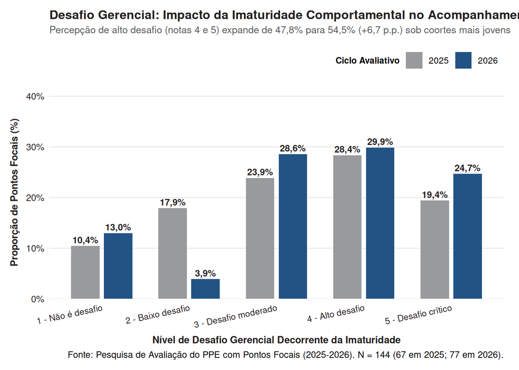

Figura 15: Percepção gerencial quanto ao desafio imposto pela imaturidade dos trabalhadores educandos.

O diagnóstico atesta a persistência de um desafio formativo central: * **Expansão do Alto Desafio (+6,7 p.p.):** A proporção de gestores que encaram a imaturidade como um desafio elevado ou crítico (notas 4 e 5) subiu de **47,8%** em 2025 para **54,5%** em 2026. Esse dado converge com os relatos qualitativos do Bloco I, que apontavam a entrada de beneficiários mais jovens com dificuldades de gerenciamento de tempo, uso excessivo de telas e desconhecimento da hierarquia funcional; * **Recuo da Baixa Dificuldade (-14,0 p.p.):** A nota 2 (“Baixo desafio”) encolheu de **17,9%** para apenas **3,9%**, sinalizando que a mediação pedagógica e disciplinar consome energia constante da chefia imediata; * **Dualidade Pedagógica:** Este achado reforça que o PPE não é uma contratação laboral ordinária, mas uma política formativa cujo sucesso depende de paciência institucional e de suporte contínuo da coordenação central.

## 7.3 Clareza dos Beneficiários quanto aos Objetivos Profissionais

A capacidade de o jovem vislumbrar seu itinerário formativo e suas aspirações ocupacionais no médio prazo foi investigada na questão `q16` (escala Likert de 1 a 5), cujos resultados figuram na Tabela 16 e na Figura 16.

Tabela 16: Percepção gerencial sobre a clareza dos beneficiários quanto aos seus objetivos profissionais (2025 vs. 2026).

| Clareza sobre Objetivos Profissionais Futuros | 2025 (N) | 2025 (%) | 2026 (N) | 2026 (%) | Variação (p.p.) |
| --- | --- | --- | --- | --- | --- |
| 1 - Discordo totalmente | 3 | 4,5% | 2 | 2,6% | -1,9 |
| 2 - Discordo em parte | 4 | 6,0% | 5 | 6,5% | +0,5 |
| 3 - Neutro / Indeciso | 22 | 32,8% | 29 | 37,7% | +4,9 |
| 4 - Concordo em parte | 26 | 38,8% | 23 | 29,9% | -8,9 |
| 5 - Concordo totalmente | 12 | 17,9% | 18 | 23,4% | +5,5 |
| Total | 67 | 100,0% | 77 | 100,0% | — |

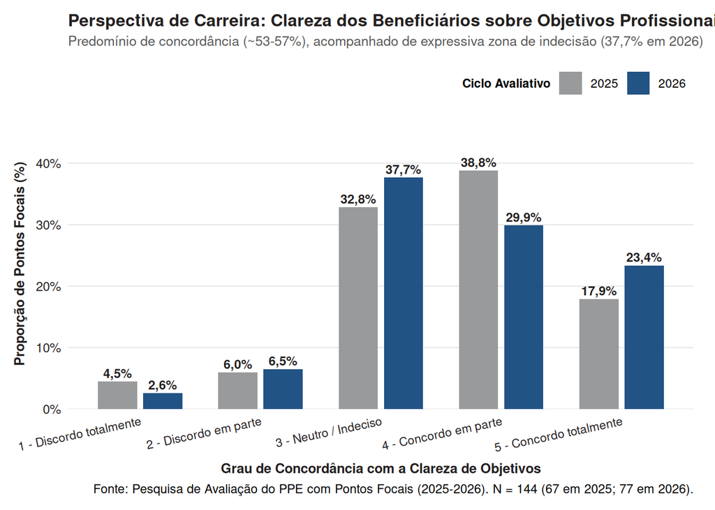

Figura 16: Distribuição da percepção sobre o direcionamento de carreira e metas futuras dos jovens.

## 7.4 Adaptação à Cultura e Rotinas do Serviço Público

A capacidade de absorver as formalidades, os princípios de impessoalidade e a ética da administração pública foi avaliada na questão `q17` (escala 1 a 5), conforme sintetizado na Tabela 17 e na Figura 17.

Tabela 17: Avaliação do grau de adaptação dos beneficiários à cultura do serviço público (2025 vs. 2026).

| Adaptação à Cultura e Rotinas do Serviço Público | 2025 (N) | 2025 (%) | 2026 (N) | 2026 (%) | Variação (p.p.) |
| --- | --- | --- | --- | --- | --- |
| 1 - Não se adaptam | 0 | 0,0% | 0 | 0,0% | 0,0 |
| 2 - Baixa adaptação | 1 | 1,5% | 1 | 1,3% | -0,2 |
| 3 - Adaptação moderada | 13 | 19,4% | 18 | 23,4% | +4,0 |
| 4 - Boa adaptação | 29 | 43,3% | 32 | 41,6% | -1,7 |
| 5 - Excelente adaptação | 24 | 35,8% | 26 | 33,8% | -2,0 |
| Total | 67 | 100,0% | 77 | 100,0% | — |

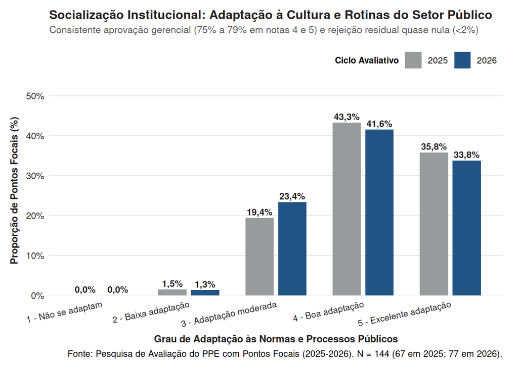

Figura 17: Grau de assimilação da cultura, normas e rotinas públicas pelos educandos do PPE.

A socialização dos jovens revela estabilidade e alta integração: * **Ampla Aprovação Gerencial (75,3% a 79,1%):** Mais de três quartos dos pontos focais atestam boa ou excelente adaptação dos beneficiários (notas 4 e 5 em ambos os anos); * **Crescimento Moderado da Cautela (+4,0 p.p.):** A avaliação moderada (nota 3) avançou ligeiramente de **19,4%** para **23,4%**, explicada pela complexidade crescente dos processos administrativos informatizados (SEI Bahia e sistemas finalísticos); * **Inadaptação Inexistente (0,0% nota 1):** Não houve registro de nota 1 (“Não se adaptam”) em nenhum dos ciclos, e a nota 2 situou-se em apenas 1 gestor (~1,3%), desmistificando resistências prévias de que os jovens não se ajustariam ao rigor funcional do Estado.

## 7.5 Relacionamento Interpessoal e Convivência com a Equipe

O indicador mais exuberante de todo o perfil socioprofissional reside na convivência com os demais servidores e terceirizados da unidade (questão `q18`, escala 1 a 5). Os números constam na Tabela 18 e na Figura 18.

Tabela 18: Avaliação do relacionamento interpessoal dos jovens com os demais trabalhadores do órgão (2025 vs. 2026).

| Relacionamento Interpessoal com a Equipe de Trabalho | 2025 (N) | 2025 (%) | 2026 (N) | 2026 (%) | Variação (p.p.) |
| --- | --- | --- | --- | --- | --- |
| 1 - Relação muito ruim | 0 | 0,0% | 0 | 0,0% | 0,0 |
| 2 - Relação ruim | 0 | 0,0% | 1 | 1,3% | +1,3 |
| 3 - Relação regular | 7 | 10,4% | 2 | 2,6% | -7,8 |
| 4 - Boa relação | 32 | 47,8% | 33 | 42,9% | -4,9 |
| 5 - Excelente relação | 28 | 41,8% | 41 | 53,2% | +11,4 |
| Total | 67 | 100,0% | 77 | 100,0% | — |

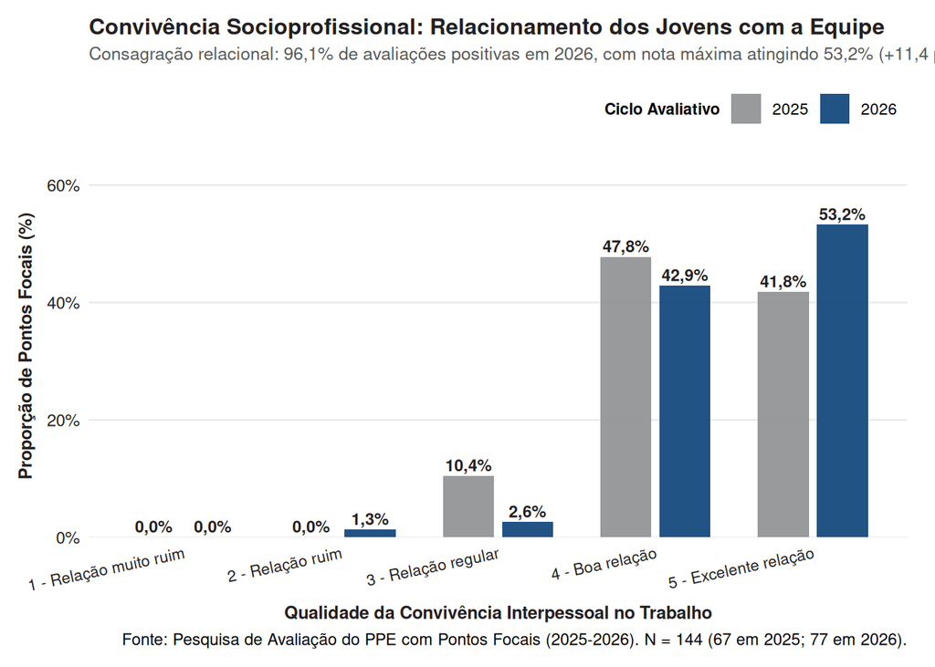

Figura 18: Qualidade do vínculo interpessoal e da harmonia dos beneficiários com o quadro institucional.

# 8 Sugestões de Aprimoramento, Inconformidades e Riscos de Gestão

O fechamento do instrumento avaliativo proporcionou aos pontos focais um espaço qualitativo aberto para manifestar reflexões propositivas e sinalizar fragilidades operacionais que escapam aos quesitos estruturados. A análise semântica das questões abertas `q19` (sugestões de aperfeiçoamento) e `q20` (inconformidades e pontos de atenção crítica) permite mapear as prioridades de reforma e os riscos institucionais que exigem intervenção da coordenação executiva do Projeto Primeiro Emprego.

## 8.1 Eixos Propositivos dos Pontos Focais para o Aprimoramento do PPE

A categorização temática das 144 manifestações da questão `q19` é detalhada na Tabela 19 e na Figura 19, evidenciando as transformações de prioridade entre 2025 e 2026.

Tabela 19: Eixos propositivos sugeridos pelos Pontos Focais para o aprimoramento contínuo do PPE (2025 vs. 2026).

| Eixo Propositivo para Aprimoramento do PPE | 2025 (N) | 2025 (%) | 2026 (N) | 2026 (%) | Variação (p.p.) |
| --- | --- | --- | --- | --- | --- |
| Comunicação ágil, canais dedicados e retornos da coordenação | 9 | 13,4% | 28 | 36,4% | +23,0 |
| Capacitação técnica e comportamental prévia e continuada | 14 | 20,9% | 23 | 29,9% | +9,0 |
| Alinhamento de perfil de lotação e regras de substituição | 10 | 14,9% | 15 | 19,5% | +4,6 |
| Suporte psicossocial, escuta e acolhimento emocional | 8 | 11,9% | 9 | 11,7% | -0,2 |
| Outras sugestões operacionais / Manutenção do formato atual | 25 | 37,3% | 2 | 2,6% | -34,7 |
| Total de Respondentes com Proposições Substantivas | 66 | 98,5% | 77 | 100,0% | — |

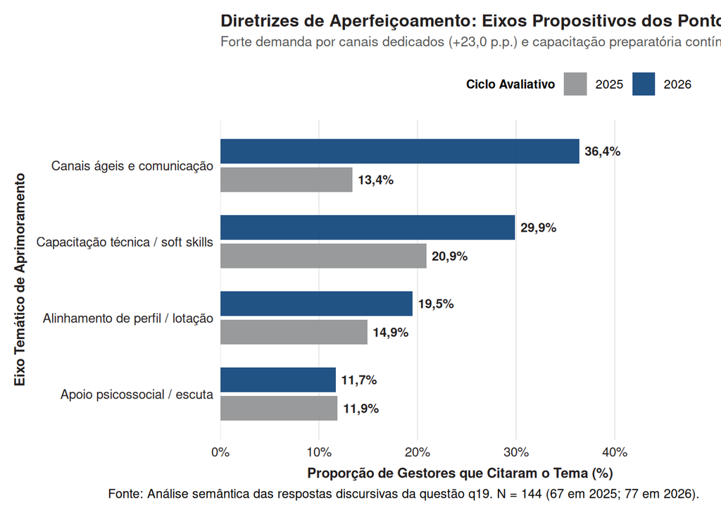

Figura 19: Distribuição percentual dos principais eixos de sugestões apresentados pelos gestores estaduais.

A análise dos relatos qualitativos revela um amadurecimento das reivindicações gerenciais: * **Explosão da Demanda por Canais Ágeis (+23,0 p.p.):** A categoria de canais dedicados e retorno célere da coordenação/entidade parceira disparou de **13,4%** em 2025 para **36,4%** em 2026 (28 gestores). Há um apelo veemente pela institucionalização de canais diretos para o gestor (como uma linha ou portal exclusivo), evitando a mistura de demandas de recursos humanos dos jovens com orientações técnicas de supervisão; * **Fortalecimento da Formação Prévia e Continuada (+9,0 p.p.):** Reivindicada por **29,9%** dos gestores em 2026 (contra **20,9%** em 2025), a capacitação em informática básica, redação oficial, ética pública e atendimento ao cidadão antes do envio ao posto é considerada decisiva para reduzir a curva de aprendizagem e minimizar o atrito geracional; * **Aprimoramento na Alocação e Critérios de Substituição (19,5%):** Os gestores solicitam maior aderência entre a formação técnica original do educando (egresso dos cursos técnicos estaduais) e as reais necessidades setoriais do órgão, além de regras claras e céleres para reposição ou remanejamento de vagas em caso de descompasso de perfil; * **Cuidado com a Saúde Mental e Escuta Emocional (~12%):** A manutenção estável do eixo psicossocial reflete a sensibilidade dos gestores frente às vulnerabilidades sociais, ansiedades e conflitos familiares vivenciados pela juventude periférica.

## 8.2 Matriz de Inconformidades Operacionais e Riscos Críticos

A identificação tempestiva de inconformidades operacionais constitui elemento basilar para a governança de risco no setor público. A categorização da questão `q20` é apresentada na Tabela 20 e na Figura 20.

Tabela 20: Categorização de inconformidades operacionais e pontos de atenção urgente apontados pelos gestores (2025 vs. 2026).

| Inconformidades Críticas e Riscos Identificados | 2025 (N) | 2025 (%) | 2026 (N) | 2026 (%) | Variação (p.p.) |
| --- | --- | --- | --- | --- | --- |
| Ausência de inconformidades / Funcionamento satisfatório | 42 | 62,7% | 47 | 61,0% | -1,7 |
| Expectativas contratuais: incerteza sobre vigência de 1 vs 2 anos | 5 | 7,5% | 7 | 9,1% | +1,6 |
| Comunicação lenta e morosidade de suporte da entidade parceira | 5 | 7,5% | 7 | 9,1% | +1,6 |
| Desvio de função, substituição de servidores e escalas de plantão | 2 | 3,0% | 5 | 6,5% | +3,5 |
| Suporte administrativo a benefícios, crachás e auxílio-transporte | 6 | 9,0% | 3 | 3,9% | -5,1 |
| Outras manifestações pontuais de conformidade operacional | 7 | 10,4% | 8 | 10,4% | 0,0 |
| Total | 67 | 100,0% | 77 | 100,0% | — |

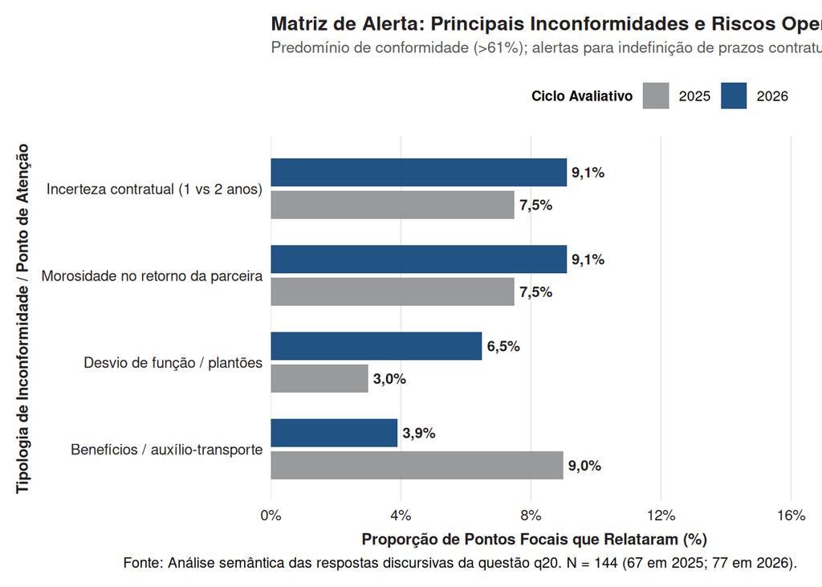

Figura 20: Principais riscos operacionais e inconformidades substantivas que demandam atenção regulatória imediata.

Os alertas gerenciais apontam dois nós críticos de governança: * **Predomínio da Regularidade Institucional (>61%):** Em ambos os ciclos, mais de 60% dos gestores declararam expressamente inexistir qualquer inconformidade (“Não”, “Nenhuma” ou elogios à condução geral), o que atesta a solidez procedimental do programa; * **A Armadilha da Expectativa Contratual (1 vs. 2 anos):** Relatada por **9,1%** dos gestores em 2026, a falta de transparência sobre a duração efetiva do contrato do jovem educando gera desgaste humano e administrativo severo. O jovem ingressa projetando uma permanência de dois anos, mas muitos contratos são encerrados ao final de um ano sem critérios transparentes prévios, gerando frustração psicológica no beneficiário e descontinuidade dos serviços no posto de trabalho; * **Riscos de Desvio de Função e Substituição Indevida (+3,5 p.p.):** Menções a desvios de atribuição e demandas para colocação dos educandos em escalas de plantão, fins de semana ou em substituição tácita a servidores efetivos cresceram para **6,5%** em 2026. A ausência de fiscalização contínua pode transfigurar a natureza pedagógica do PPE em mão de obra precarizada de custeio administrativo; * **Pontualidade de Benefícios e Suporte Básico:** Atrasos na liberação de recargas de auxílio-transporte e demora na emissão de crachás institucionais recuaram de **9,0%** para **3,9%**, demonstrando ganhos de eficiência logística da entidade gestora.

# 9 Considerações Finais e Recomendações Estratégicas de Gestão

O presente estudo comparativo longitudinal (2025–2026) consolida a perspectiva analítica dos **Pontos Focais**, revelando que o Projeto Primeiro Emprego (PPE) atingiu um estágio maduro de institucionalização e legitimidade perante o funcionalismo público do Estado da Bahia. Longe de ser compreendido como mero suprimento contingencial de força de trabalho, o programa consolidou-se como uma política de desenvolvimento humano e inclusão produtiva amplamente valorizada pelas chefias imediatas.

## 9.2 Recomendações Estratégicas Aplicadas para a Governança do PPE

Com base no diagnóstico empírico dos 144 relatos e dados tabulares, formulam-se as seguintes recomendações para a Secretaria da Administração (SAEB), a Secretaria do Trabalho, Emprego, Renda e Esporte (SETRE) e as entidades parceiras operacionais executoras (FESF-SUS / FLEM):

### 9.2.1 1. Implantação do Portal Digital do Gestor e Central de Chamados

Substituir a dependência excessiva de grupos informais de WhatsApp por uma plataforma unificada de autosserviço para os Pontos Focais. O sistema deve permitir a homologação eletrônica de frequência, consulta de atestados, emissão de declarações e abertura de chamados com prazos acordados (*SLAs*) para reposição de vagas e esclarecimento de dúvidas.

### 9.2.2 2. Normatização Transparente dos Prazos e Vigência Contratual (1 vs. 2 Anos)

Publicar instrução normativa conjunta explicitando de forma inequívoca os critérios objetivos para renovação do contrato do jovem por mais 12 meses (totalizando 24 meses) ou para o encerramento no 12º mês. Essa medida eliminará a ansiedade dos jovens, conferirá previsibilidade aos postos de trabalho e desonerará os gestores locais de pressões psicológicas indevidas.

### 9.2.3 3. Programa Permanente de Formação Socioemocional e Ética Pública (*Onboarding*)

Intensificar os módulos preparatórios pré-admissão focando em *soft skills*: gerenciamento do tempo, comunicação formal corporativa, etiqueta digital, sigilo institucional e uso adequado de dispositivos móveis. Paralelamente, instituir oficinas curtas de liderança e mentoria empática voltadas exclusivamente aos pontos focais.

### 9.2.4 4. Fortalecimento da Fiscalização contra o Desvio de Finalidade

Reiterar nos termos de cooperação a proibição estrita de alocação de beneficiários do PPE em escalas extraordinárias de plantão noturno ou em funções finalísticas permanentes de carreira, preservando o caráter eminentemente pedagógico-formativo da política de primeiro emprego.

### 9.2.5 5. Reconhecimento Institucional e Carga Horária Protegida para a Mentoria

Formalizar nos assentamentos funcionais dos pontos focais a sua atuação como tutores de formação profissional e prever, nas rotinas departamentais, uma carga horária semanal protegida de até 2 horas dedicada exclusivamente ao diálogo pedagógico e acompanhamento dos jovens.

# Referências Bibliográficas

BENOIT, Kenneth; MUHR, David; WATANABE, Kohei. **[stopwords: Multilingual Stopword Lists](https://CRAN.R-project.org/package=stopwords)**. *[S.l.: S.n.]*.

ENGLER, Jan Broder. **[tidyplots: Tidy Plots for Scientific Papers](https://CRAN.R-project.org/package=tidyplots)**. *[S.l.: S.n.]*.

LE COMTE, Erwan. **[ggwordcloud: A Word Cloud Geom for ggplot2](https://CRAN.R-project.org/package=ggwordcloud)**. *[S.l.: S.n.]*.

R CORE TEAM. **[R: A Language and Environment for Statistical Computing](https://www.R-project.org/)**. Vienna, Austria: R Foundation for Statistical Computing, 2024.

SILGE, Julia; ROBINSON, David. [tidytext: Text Mining and Analysis Using Tidy Data Principles in R](https://doi.org/10.21105/joss.00037). **JOSS**, v. 1, n. 3, p. 37, 2016.

WICKHAM, Hadley. **[ggplot2: Elegant Graphics for Data Analysis](https://ggplot2.tidyverse.org)**. *[S.l.]*: Springer-Verlag New York, 2016.

WICKHAM, Hadley *et al.* [Welcome to the tidyverse](https://doi.org/10.21105/joss.01686). **Journal of Open Source Software**, v. 4, n. 43, p. 1686, 2019.

WICKHAM, Hadley *et al.* **[dplyr: A Grammar of Data Manipulation](https://CRAN.R-project.org/package=dplyr)**. *[S.l.: S.n.]*.

WICKHAM, Hadley. **[stringr: Simple, Consistent Wrappers for Common String Operations](https://CRAN.R-project.org/package=stringr)**. *[S.l.: S.n.]*.

WICKHAM, Hadley; PEDERSEN, Thomas Lin; SEIDEL, Dana. **[scales: Scale Functions for Visualization](https://CRAN.R-project.org/package=scales)**. *[S.l.: S.n.]*.

XIE, Yihui. **[knitr: A General-Purpose Package for Dynamic Report Generation in R](https://yihui.org/knitr/)**. *[S.l.: S.n.]*.